# IODS course project

## Scale the data

```r
#standardize and scale the variables using scale -function
boston_scaled <- scale(Boston)

#see how the new variables look
summary(boston_scaled)
```

```
##       crim                 zn               indus              chas
##  Min.   :-0.419367   Min.   :-0.48724   Min.   :-1.5563   Min.   :-0.2723
##  1st Qu.:-0.410563   1st Qu.:-0.48724   1st Qu.:-0.8668   1st Qu.:-0.2723
##  Median :-0.390280   Median :-0.48724   Median :-0.2109   Median :-0.2723
##  Mean   : 0.000000   Mean   : 0.00000   Mean   : 0.0000   Mean   : 0.0000
##  3rd Qu.: 0.007389   3rd Qu.: 0.04872   3rd Qu.: 1.0150   3rd Qu.:-0.2723
##  Max.   : 9.924110   Max.   : 3.80047   Max.   : 2.4202   Max.   : 3.6648
##       nox                rm               age               dis
##  Min.   :-1.4644   Min.   :-3.8764   Min.   :-2.3331   Min.   :-1.2658
##  1st Qu.:-0.9121   1st Qu.:-0.5681   1st Qu.:-0.8366   1st Qu.:-0.8049
##  Median :-0.1441   Median :-0.1084   Median : 0.3171   Median :-0.2790
##  Mean   : 0.0000   Mean   : 0.0000   Mean   : 0.0000   Mean   : 0.0000
##  3rd Qu.: 0.5981   3rd Qu.: 0.4823   3rd Qu.: 0.9059   3rd Qu.: 0.6617
##  Max.   : 2.7296   Max.   : 3.5515   Max.   : 1.1164   Max.   : 3.9566
##       rad               tax             ptratio            black
##  Min.   :-0.9819   Min.   :-1.3127   Min.   :-2.7047   Min.   :-3.9033
##  1st Qu.:-0.6373   1st Qu.:-0.7668   1st Qu.:-0.4876   1st Qu.: 0.2049
##  Median :-0.5225   Median :-0.4642   Median : 0.2746   Median : 0.3808
##  Mean   : 0.0000   Mean   : 0.0000   Mean   : 0.0000   Mean   : 0.0000
##  3rd Qu.: 1.6596   3rd Qu.: 1.5294   3rd Qu.: 0.8058   3rd Qu.: 0.4332
##  Max.   : 1.6596   Max.   : 1.7964   Max.   : 1.6372   Max.   : 0.4406
##      lstat              medv
##  Min.   :-1.5296   Min.   :-1.9063
##  1st Qu.:-0.7986   1st Qu.:-0.5989
##  Median :-0.1811   Median :-0.1449
##  Mean   : 0.0000   Mean   : 0.0000
##  3rd Qu.: 0.6024   3rd Qu.: 0.2683
##  Max.   : 3.5453   Max.   : 2.9865
```

```r
# change the object to data frame for later use
boston_scaled <- as.data.frame(boston_scaled)
```

In the original data all the values have different ranges of variation. After we scale them, all the mean values became 0 and the variations of the variables are on the same scale.

In the research, it is more meaningful and informative that crime can be examined in more informative way, than just a numerical value. By changing the originally numerical data into a categorical one, we can more easily draw conclusions about which areas have low, medium low, medium high or high crime rates. To do that we first need to know the distribution of the data and define reasonable boundaries for desired categories.

```r
#create vector for bins
bins <- quantile(boston_scaled$crim)
bins
```

```
##           0%          25%          50%          75%         100%
## -0.419366929 -0.410563278 -0.390280295  0.007389247  9.924109610
```

```r
#new variable that includes the different bins for crime
crime <- cut(boston_scaled$crim, breaks = bins, include.lowest = TRUE, label= c("low", "med_low", "med_high", "high"))

#How many values are in each bin
table(crime)
```

```
## crime
##      low  med_low med_high     high
##      127      126      126      127
```

```r
#remove original crim from the dataset
boston_scaled <- dplyr::select(boston_scaled, -crim)

#add the new variable in the data set
boston_scaled <- data.frame(boston_scaled, crime)
```

Now we have categorized the crime variable in a way that all the classes have almost the same amount of rows in them.

## Test and Train

To test and train the data, we need to divide the original data into 80% that will be used to train the algorithm and 20% that will be used to see how well the algorithm works.

```r
# safe the number of rows in the data
n <- nrow(boston_scaled)

# choose randomly 80% of the rows
ind <- sample(n,  size = n * 0.8)

# create train set from those 80%
train <- boston_scaled[ind,]

# create test set from the rest 20%
test <- boston_scaled[-ind,]
```

## Linear discriminant analysis

Now that we have own data for training and own data for testing, we can start doing the linear discriminant analysis.

```r
# Safe the analysis in the new variable
lda.fit <- lda(crime~., data = train)

#"Summary" of the analysis
lda.fit
```

```
## Call:
## lda(crime ~ ., data = train)
##
## Prior probabilities of groups:
##       low   med_low  med_high      high
## 0.2475248 0.2574257 0.2450495 0.2500000
##
## Group means:
##                   zn      indus        chas        nox          rm        age
## low       0.94142600 -0.9816082 -0.15421606 -0.8892658  0.54596677 -0.9076353
## med_low  -0.02960921 -0.3269553 -0.04518867 -0.5989727 -0.09958614 -0.4387695
## med_high -0.38156320  0.1773459  0.12535782  0.3796401  0.15605717  0.4398997
## high     -0.48724019  1.0171306 -0.11640431  1.0230829 -0.40703650  0.8164989
##                 dis        rad        tax     ptratio       black       lstat
## low       0.8296096 -0.6855667 -0.7472962 -0.41919466  0.39101617 -0.82715479
## med_low   0.4252022 -0.5412574 -0.4947360 -0.07406251  0.31957741 -0.19239837
## med_high -0.3745862 -0.4238786 -0.3184551 -0.27106767  0.06453956 -0.01444663
## high     -0.8444738  1.6379981  1.5139626  0.78062517 -0.81322362  0.87663509
##                 medv
## low       0.62630515
## med_low   0.04922969
## med_high  0.18094428
## high     -0.67693869
##
## Coefficients of linear discriminants:
##                 LD1         LD2         LD3
## zn       0.05577776  0.64108104 -0.94739465
## indus    0.08099667 -0.42306709  0.40420000
## chas    -0.11105506 -0.05451404  0.18209070
## nox      0.42622618 -0.76259302 -1.26685976
## rm      -0.09861097 -0.12326187 -0.22554970
## age      0.19694766 -0.40256624 -0.18993705
## dis     -0.03351893 -0.35196556  0.28094325
## rad      3.37424316  0.89607987 -0.03685967
## tax      0.02524142  0.12328976  0.44267404
## ptratio  0.09185362  0.03882965 -0.33065943
## black   -0.11246964  0.03176759  0.12545652
## lstat    0.27394296 -0.16241705  0.39982793
## medv     0.21900364 -0.35230099 -0.15834441
##
## Proportion of trace:
##    LD1    LD2    LD3
## 0.9524 0.0358 0.0118
```

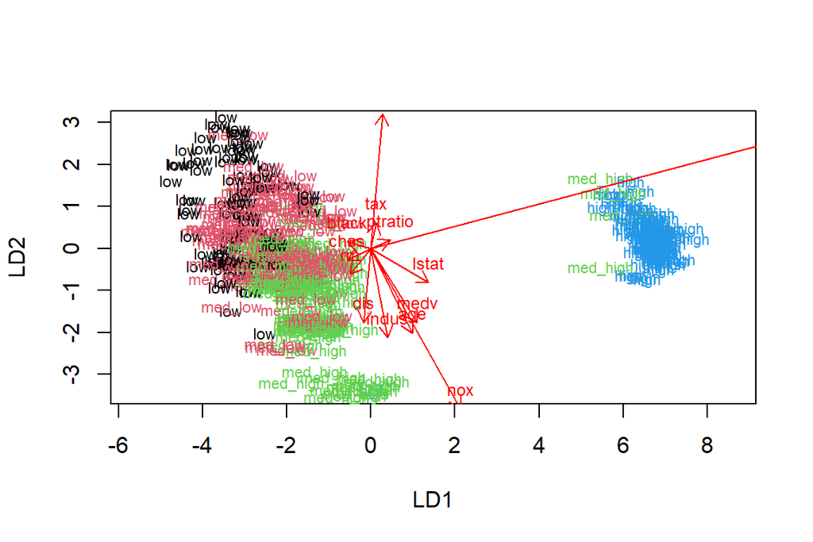

```r
# the function for lda biplot arrows
lda.arrows <- function(x, myscale = 1, arrow_heads = 0.1, color = "red", tex = 0.75, choices = c(1,2)){
  heads <- coef(x)
  graphics::arrows(x0 = 0, y0 = 0,
         x1 = myscale * heads[,choices[1]],
         y1 = myscale * heads[,choices[2]], col=color, length = arrow_heads)
  text(myscale * heads[,choices], labels = row.names(heads),
       cex = tex, col=color, pos=3)
}

# target classes as numeric
classes <- as.numeric(train$crime)

# Plot the results and wanted arrows
plot(lda.fit, dimen = 2, col = classes, pch = classes)
lda.arrows(lda.fit, myscale = 5)
```

Now the training is done, so it is time to test how well the algorithm works. First it is needed to safe the correct values in a different variable and remove them form the test data. This way they cannot affect the results of the analysis, which would almost inevitably happen if they remained in the test material.

```r
#Safe the crime categories from the test set
correct_classes <- test$crime

# remove crime from test set
test <- dplyr::select(test, -crime)
```

And now the test part:

```r
# predict classes with test aka the 20% of the original data
lda.pred <- predict(lda.fit, newdata = test)

# cross tabulate the results
table(correct = correct_classes, predicted = lda.pred$class)
```

```
##           predicted
## correct    low med_low med_high high
##   low       15      10        2    0
##   med_low    1      17        4    0
##   med_high   1      11       13    2
##   high       0       0        0   26
```

## Distance analysis

```r
#reload the data
library(MASS)
data("Boston")

#Scale the data set
Boston_standard <- scale(Boston)

#Look how the scaled data looks
summary(Boston_standard)
```

```
##       crim                 zn               indus              chas
##  Min.   :-0.419367   Min.   :-0.48724   Min.   :-1.5563   Min.   :-0.2723
##  1st Qu.:-0.410563   1st Qu.:-0.48724   1st Qu.:-0.8668   1st Qu.:-0.2723
##  Median :-0.390280   Median :-0.48724   Median :-0.2109   Median :-0.2723
##  Mean   : 0.000000   Mean   : 0.00000   Mean   : 0.0000   Mean   : 0.0000
##  3rd Qu.: 0.007389   3rd Qu.: 0.04872   3rd Qu.: 1.0150   3rd Qu.:-0.2723
##  Max.   : 9.924110   Max.   : 3.80047   Max.   : 2.4202   Max.   : 3.6648
##       nox                rm               age               dis
##  Min.   :-1.4644   Min.   :-3.8764   Min.   :-2.3331   Min.   :-1.2658
##  1st Qu.:-0.9121   1st Qu.:-0.5681   1st Qu.:-0.8366   1st Qu.:-0.8049
##  Median :-0.1441   Median :-0.1084   Median : 0.3171   Median :-0.2790
##  Mean   : 0.0000   Mean   : 0.0000   Mean   : 0.0000   Mean   : 0.0000
##  3rd Qu.: 0.5981   3rd Qu.: 0.4823   3rd Qu.: 0.9059   3rd Qu.: 0.6617
##  Max.   : 2.7296   Max.   : 3.5515   Max.   : 1.1164   Max.   : 3.9566
##       rad               tax             ptratio            black
##  Min.   :-0.9819   Min.   :-1.3127   Min.   :-2.7047   Min.   :-3.9033
##  1st Qu.:-0.6373   1st Qu.:-0.7668   1st Qu.:-0.4876   1st Qu.: 0.2049
##  Median :-0.5225   Median :-0.4642   Median : 0.2746   Median : 0.3808
##  Mean   : 0.0000   Mean   : 0.0000   Mean   : 0.0000   Mean   : 0.0000
##  3rd Qu.: 1.6596   3rd Qu.: 1.5294   3rd Qu.: 0.8058   3rd Qu.: 0.4332
##  Max.   : 1.6596   Max.   : 1.7964   Max.   : 1.6372   Max.   : 0.4406
##      lstat              medv
##  Min.   :-1.5296   Min.   :-1.9063
##  1st Qu.:-0.7986   1st Qu.:-0.5989
##  Median :-0.1811   Median :-0.1449
##  Mean   : 0.0000   Mean   : 0.0000
##  3rd Qu.: 0.6024   3rd Qu.: 0.2683
##  Max.   : 3.5453   Max.   : 2.9865
```

```r
#calculate the distances
dist_boston <- dist(Boston_standard)

# look at the summary of the distances
summary(dist_boston)
```

```
##    Min. 1st Qu.  Median    Mean 3rd Qu.    Max.
##  0.1343  3.4625  4.8241  4.9111  6.1863 14.3970
```